# AMRS Intercomparison Round 3

Kevin Styers , Natchya Durden , David Durden , Stefan Metzger , Hongyan Luo  
2021-12-06

# Executive Summary

An intercomparison analysis was performed to assess the potential differences between AMRS values when configured with different firmware versions.

*Recommendation:*

> We propose that the two test firmware versions; 01.04.05 and 01.05.01, be approved based upon the results of the analysis. One test sensor appeared to be faulty, but the other test sensor showed very little change between firmware changes and passed the majority of our tests.

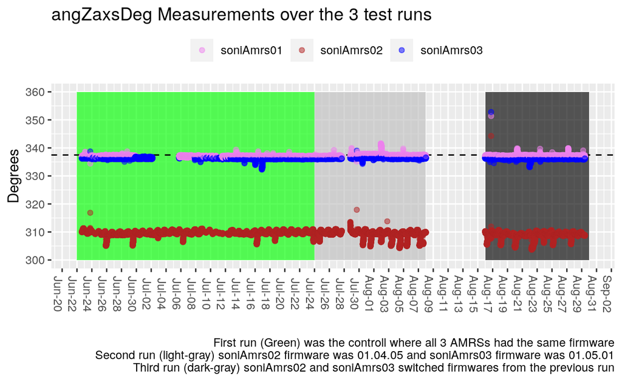

# Purpose

To access the potential impact of using the two non-tested AMRS firmware versions to see if there are any data quality concerns

# Background

Several AMRS firmware versions are currently deployed in the field with various states of Science approval. State as of 2020-02-05:

- 30 sites with `01.04.01` (approved version)
- 1 site with `01.07.02` (approved version)
- 5 sites with `01.05.01` that was not recommended based on the 1st round of test, and should retest it;
- 9 sites with `01.04.05` that wasn’t tested.
- 2 sites unknown due to earthquakes and sensor refreshes.

Currently the manufacturer declined to lockdown a specific firmware version to sell to NEON. Given this situation, we must test unapproved firmware versions and verify their ability to integrate into the ECTE system to ensure we are delivering scientific data that are consistently within NEON requirements. As the observatory ages, current AMRS’s firmware versions will go through obsolescence and must be replaced with newer firmware. To alleviate data quality and interoperability concerns across NEON sites we must test the unapproved firmware versions that are currently deployed, as well as any new firmware versions NEON receives from the manufacturer.

Summary of previous tests:

1. The 1st round of AMRS comparison test was finished and reported the results in October 2018, approving the firmware version of `01.04.01` and `01.07.02`.
2. The 2nd round of AMRS comparison test was finished and reported results to IS IPT and sent to stakeholders in October 2020 and updated in RITM0019428. The recommendation was that moving forward the AMRS filter setting should be “general”, not “low_mag”.
3. For the 3rd round of AMRS tests, NEON shall test the two most widely deployed and unapproved firmware versions (`01.04.05` and `01.05.01`) against the most widely deployed and approved firmware version (`01.04.01`)

# Method

soniAmrs01 was our control unit, configured with firmware version `01.04.01` for the entire experiment duration.

- Run 1 Configuration [2021-06-22 - 2021-07-23]
  - soniAMRS01 - **01.04.01**
  - soniAMRS02 - **01.04.01**
  - soniAMRS03 - **01.04.01**
- Run 2 Configuration [2021-07-24 - 2021-08-07]
  - soniAMRS01 - **01.04.01**
  - soniAMRS02 - **01.04.05**
  - soniAMRS03 - **01.05.01**
- Run 3 Configuration [2021-08-16 - 2021-08-29]
  - soniAMRS01 - **01.04.01**
  - soniAMRS02 - **01.05.01**
  - soniAMRS03 - **01.04.05**

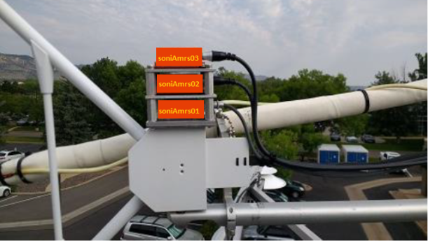

AMRS Experimental Design